O2G Supply-Demand MAP

Fit Report

seed71

# O2G Supply-Demand MAP Fit Report

**Fit Label:** seed71  
**Generated At:** 2026-05-17 18:19:04 EDT

## 1. Fit Summary

| metric | value |
| --- | --- |
| optimizer_method | DEoptim_parallel_plus_LBFGSB_serial |
| objective | 5.849 |
| objective_data | 5.722 |
| objective_prior_raw | 4.223 |
| objective_prior | 0.127 |
| objective_burden | 0.982 |
| objective_ploidy | 4.740 |
| objective_burden_neg2loglik_raw | 193.101 |
| objective_ploidy_neg2loglik_raw | 66762.383 |

## 2. Parameters

### Best Parameters

| parameter | parameter_description | value |
| --- | --- | --- |
| lam_min | baseline division rate lam_min in day^-1 | 0.073 |
| lam_max | maximum division rate lam_max in day^-1 | 0.184 |
| o2_min |  | 0.500 |
| p_mis_base | baseline per-chromosome missegregation probability | 1.354e-06 |
| p_misseg | stress-linked missegregation amplification scale | 0.400 |
| k_o_mis | half-saturation scale for death-linked missegregation amplification in day^-1 | 0.001 |
| buffer_smax | maximum per-copy survival factor for symmetric buffering missegregation survival | 0.935 |
| buffer_beta | ploidy-buffering strength for symmetric missegregation survival | 0.417 |
| buffer_n_exp | ploidy-buffering exponent for symmetric missegregation survival | 10 |
| p_wgd | constant per-division whole-genome doubling probability | 2.497e-05 |
| o2_S0 | supply-demand oxygen baseline S0 in percent O2 | 3.887 |
| kappa_O | oxygen drop coefficient in the logarithmic O2 target model | 0.373 |
| eta_o2 | ploidy-weighted oxygen demand exponent | 1.274 |
| rho_2N | 2N cell density in cells per mm^3 | 58161.446 |
| alpha_o2 | soft oxygen-mediated high-ploidy growth penalty strength | 0.500 |
| gamma_growth | exponent for the soft oxygen-mediated ploidy growth penalty | 1.509 |
| mu_hp | soft thresholded high-ploidy hypoxia death strength in day^-1 | 0.002 |
| gamma_mu | exponent for high-ploidy hypoxia death above diploid reference | 3.113 |
| O2_crit | Hill critical oxygen scale for the oxygen-response weight | 1.488 |
| n_O | Hill exponent for the oxygen-response weight | 4.499 |
| k_clear | true dead-cell clearance rate in day^-1 | 1.016e-04 |
| sigma_burden | burden log-normal observation SD | 0.600 |
| tau_O2 | oxygen relaxation time constant when fit_tau_O2 is enabled | 0.100 |
| c_vol_2N_eff_mm3 |  | 1.719e-05 |
| ratio_4N_2N |  | 1 |
| alpha | treatment-effect scale active only when fit_treatment is TRUE | 0 |
| gamma | treatment-effect exponent active only when fit_treatment is TRUE | 1 |

## 3. Figures

## 3.1 Burden

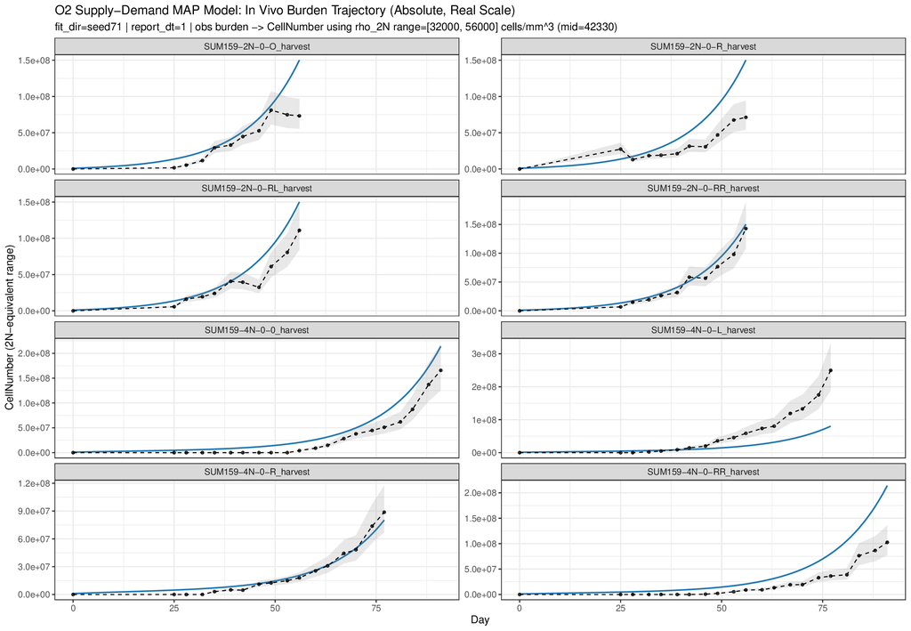

**Figure 1.1 Burden Trend Absolute (Real Scale)**

Absolute tumor burden shown on the real scale across observation times.

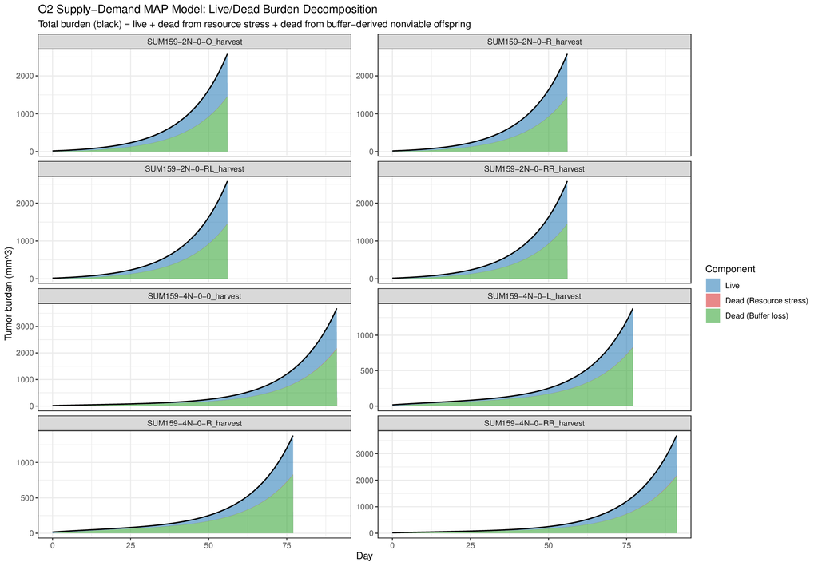

**Figure 1.2 Burden Live/Dead Decomposition**

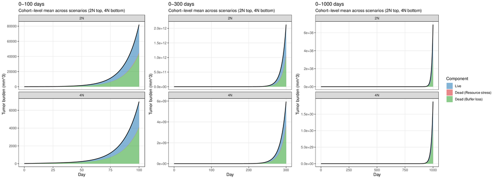

**Figure 1.3 Predicted Burden Live/Dead Decomposition (0-100/300/1000 day)**

Forward simulations from day 0 to 100, 300, and 1000 showing the predicted live/resource stress/buffer burden decomposition with a shared component legend.

## 3.2 Ploidy

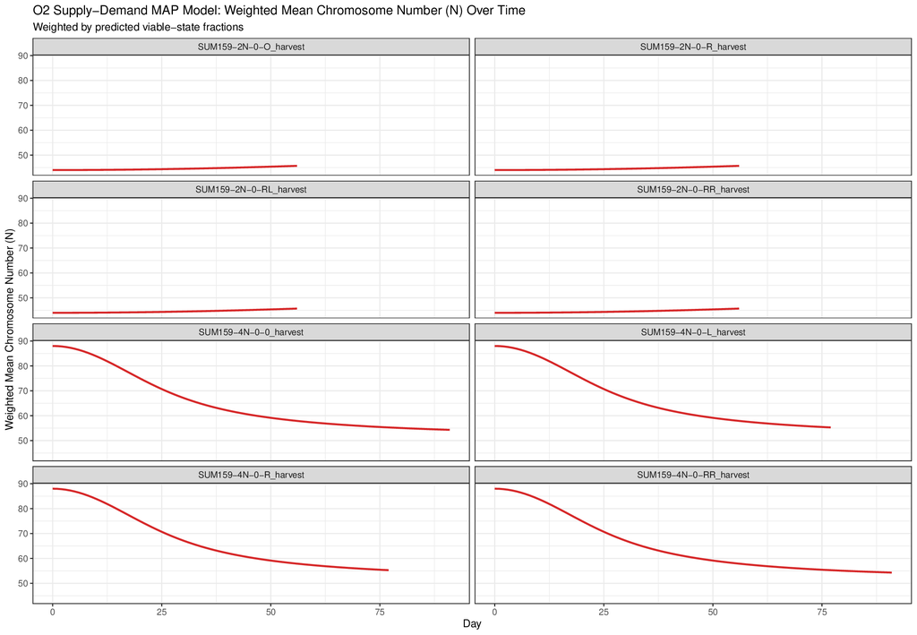

**Figure 2.1 Weighted Mean Ploidy Over Time**

Weighted mean chromosome-state trajectory over time under the fitted model.

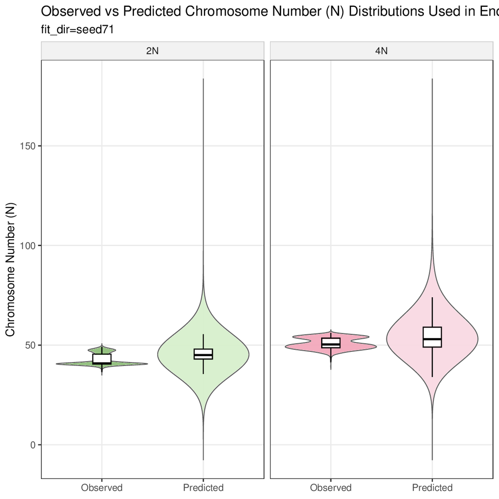

**Figure 2.2 Terminal Ploidy Observed vs Predicted**

Observed and predicted terminal ploidy or chromosome-number distributions at harvest.

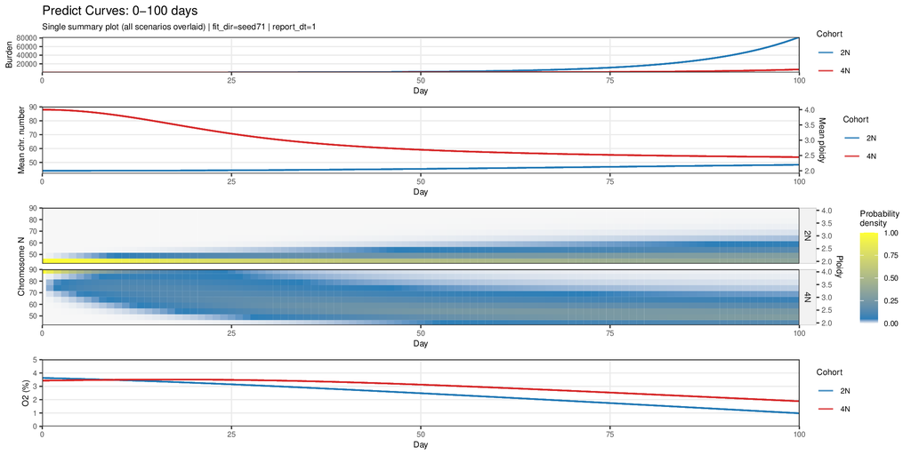

**Figure 2.3 Predicted Curves (0-100 day)**

Forward simulation from day 0 to 100 summarizing predicted burden, ploidy, and O2 trajectories.

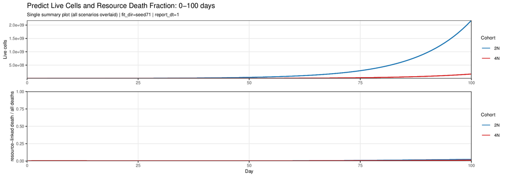

**Figure 2.4 Predicted Live Cells and Resource Death Fraction (0-100 day)**

Forward simulation from day 0 to 100 showing predicted live cells and the resource stress death fraction among all deaths.

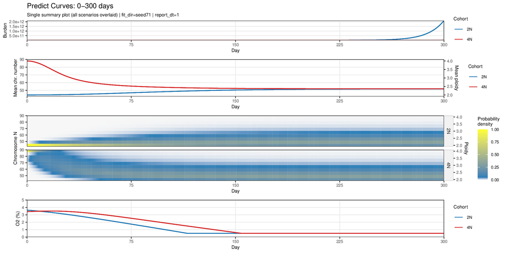

**Figure 2.5 Predicted Curves (0-300 day)**

Forward simulation from day 0 to 300 summarizing predicted burden, ploidy, and O2 trajectories.

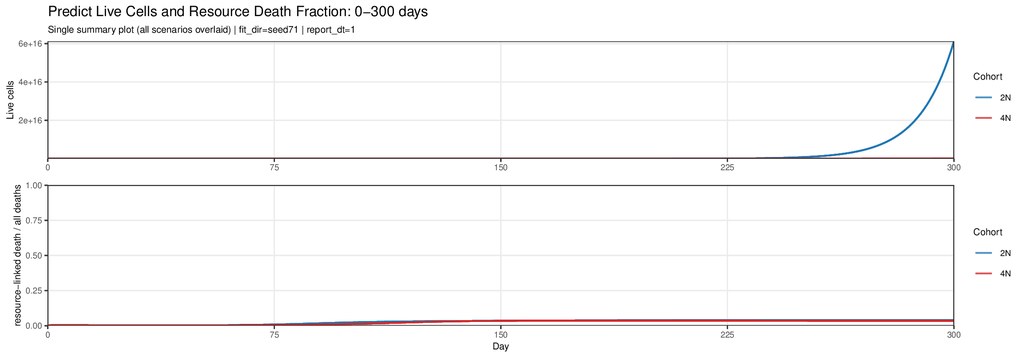

**Figure 2.6 Predicted Live Cells and Resource Death Fraction (0-300 day)**

Forward simulation from day 0 to 300 showing predicted live cells and the resource stress death fraction among all deaths.

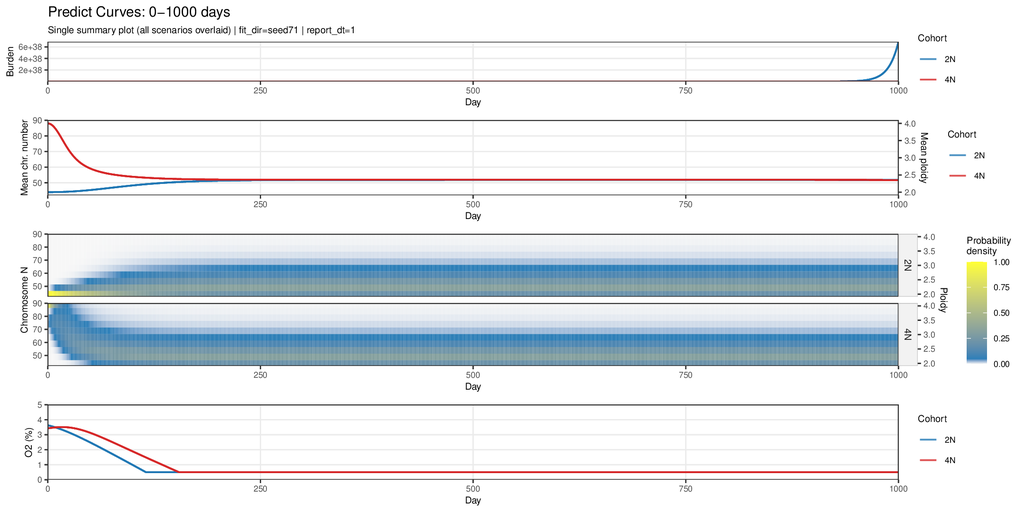

**Figure 2.7 Predicted Curves (0-1000 day)**

Forward simulation from day 0 to 1000 summarizing predicted burden, ploidy, and O2 trajectories.

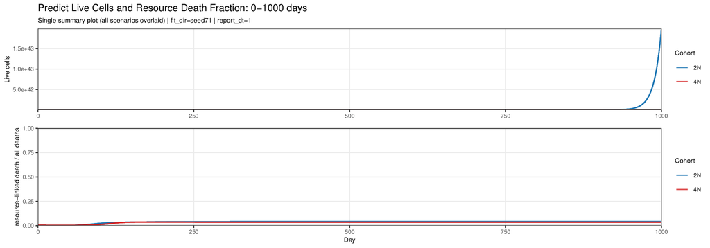

**Figure 2.8 Predicted Live Cells and Resource Death Fraction (0-1000 day)**

Forward simulation from day 0 to 1000 showing predicted live cells and the resource stress death fraction among all deaths.

## 3.3 Oxygen / O2

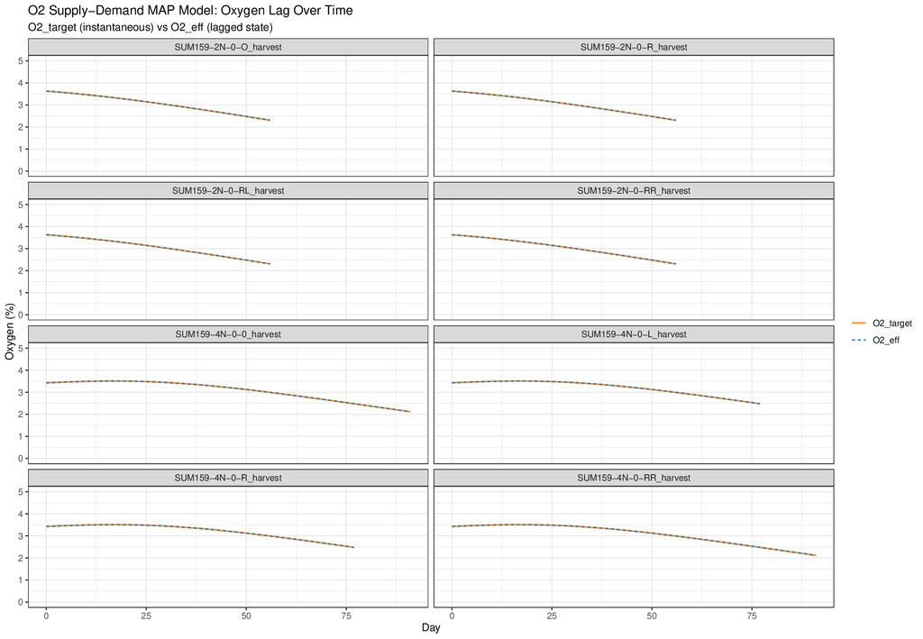

**Figure 3.1 O2 Target vs Effective Timecourse**

Timecourse comparison between the oxygen target and the lagged effective oxygen state used by the model.

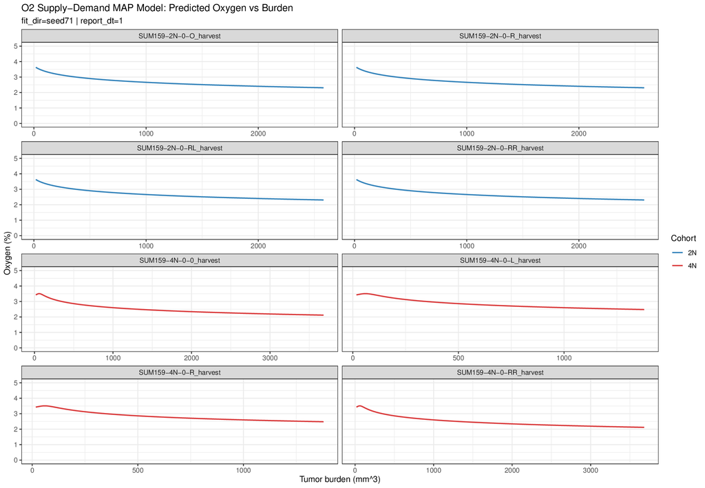

**Figure 3.2 Predicted Burden vs O2**

Forward-simulation burden trajectories plotted against the effective oxygen state.

#### 3.3.3 MS-Linked Viability and Death Relationships

Missegregation-linked viability, nonviable daughter production, and death-rate relationships.

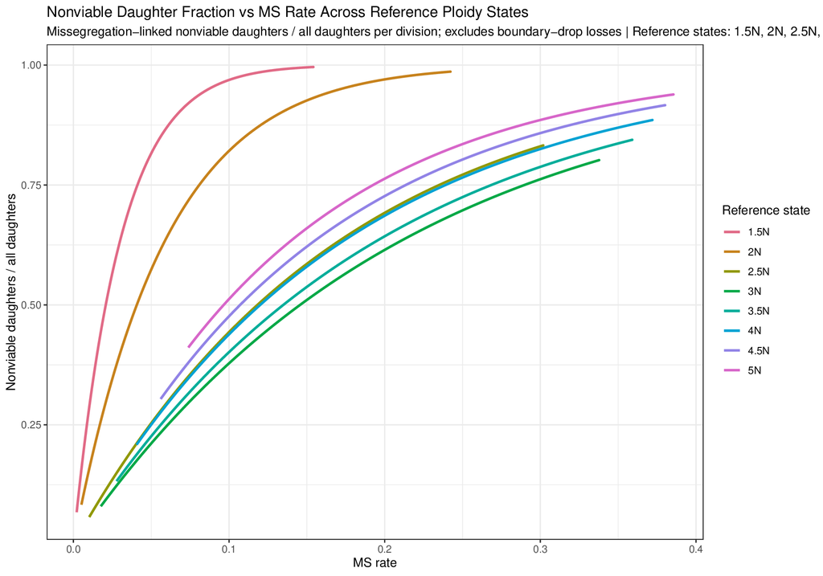

**Figure 3.3.3.1 Nonviable Daughter Fraction vs MS Rate**

Per-division fraction of daughter cells that are nonviable because of missegregation-linked loss, shown against missegregation rate.

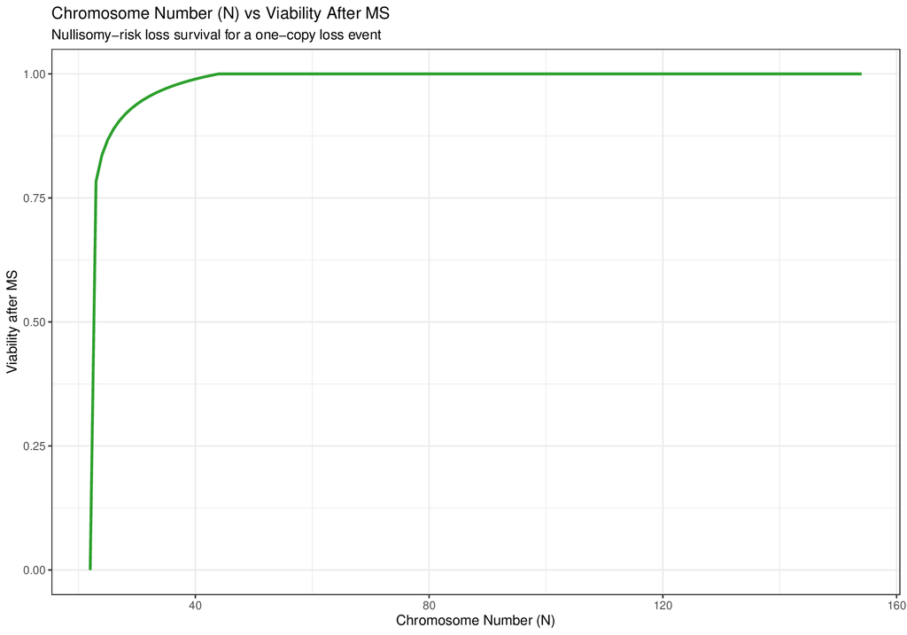

**Figure 3.3.3.2 Ploidy vs Viability After MS**

Viability modifier after a one-copy-loss missegregation event across the ploidy grid.

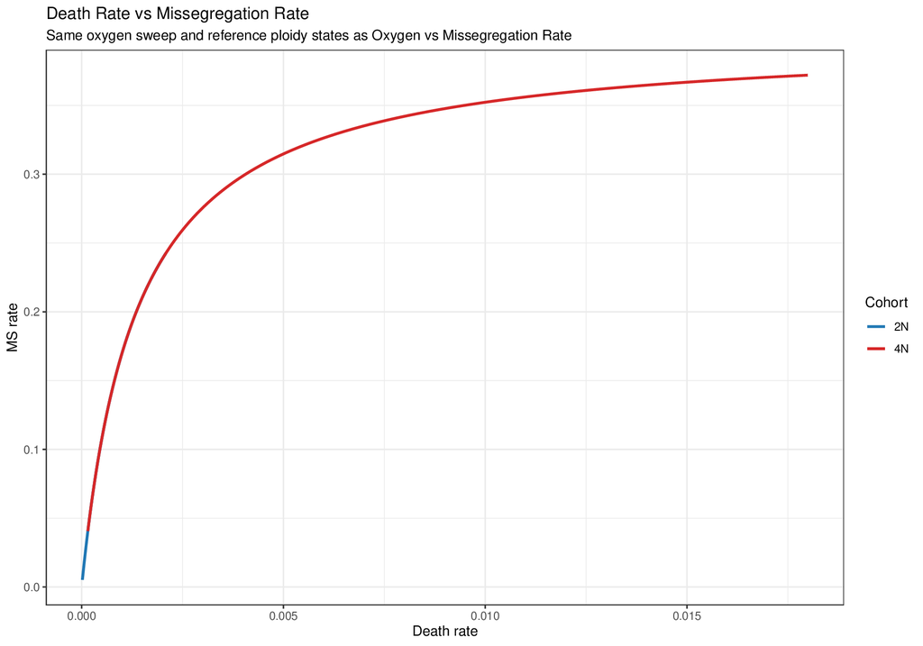

**Figure 3.3.3.3 Death Rate vs Missegregation Rate**

Missegregation-rate curve plotted against the fitted death rate at the 2N and 4N reference ploidy states.

#### 3.3.4 Coupled-G vs Fixed-G20 O2 and Ploidy Diagnostics

Side-by-side comparisons of original coupled G=O2 diagnostics against fixed G=20 diagnostics.

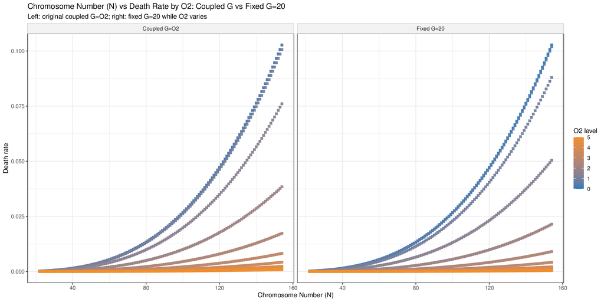

**Figure 3.3.4.1 Ploidy vs Death Rate by O2: Coupled G vs Fixed G=20**

Side-by-side comparison of the original coupled G=O2 diagnostic and the fixed-G=20 diagnostic.

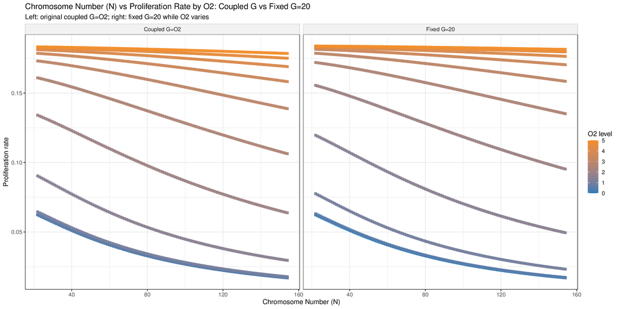

**Figure 3.3.4.2 Ploidy vs Proliferation Rate by O2: Coupled G vs Fixed G=20**

Side-by-side comparison of the original coupled G=O2 diagnostic and the fixed-G=20 diagnostic.

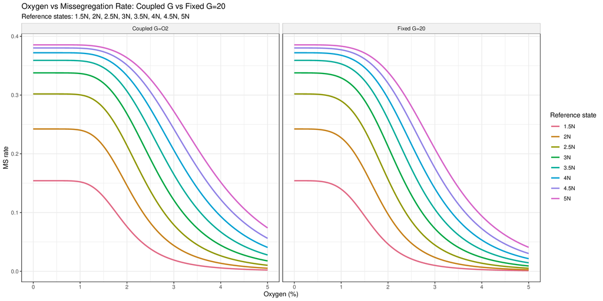

**Figure 3.3.4.3 Oxygen vs Missegregation Rate: Coupled G vs Fixed G=20**

Side-by-side comparison of oxygen-response MS curves under coupled G=O2 and fixed G=20.

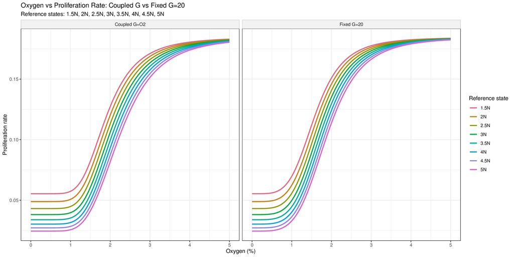

**Figure 3.3.4.4 Oxygen vs Proliferation Rate: Coupled G vs Fixed G=20**

Side-by-side comparison of oxygen-response proliferation curves under coupled G=O2 and fixed G=20.

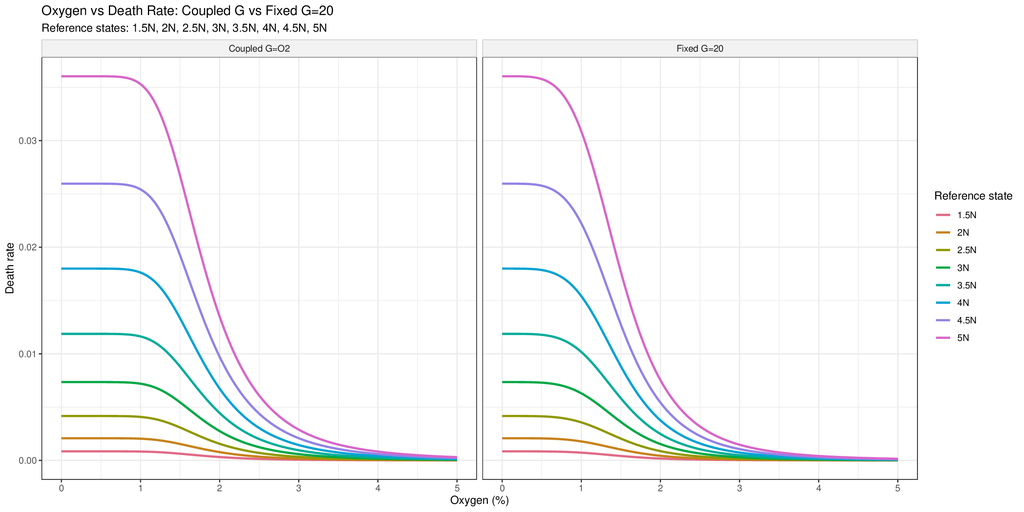

**Figure 3.3.4.5 Oxygen vs Death Rate: Coupled G vs Fixed G=20**

Side-by-side comparison of oxygen-response death-rate curves under coupled G=O2 and fixed G=20.

#### 3.3.5 G-O2-Ploidy Rate Maps

Paired G-O2 heatmaps for growth, death, and MS rate at 2N and 4N.

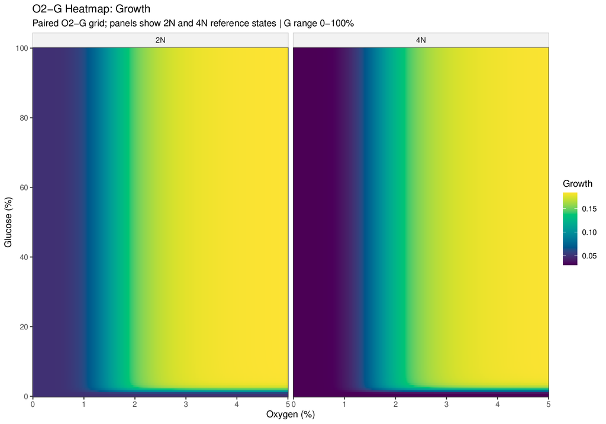

**Figure 3.3.5.1 O2-G Heatmap: Growth**

Paired oxygen-glucose grid for fitted proliferation rate; left panel is 2N and right panel is 4N.

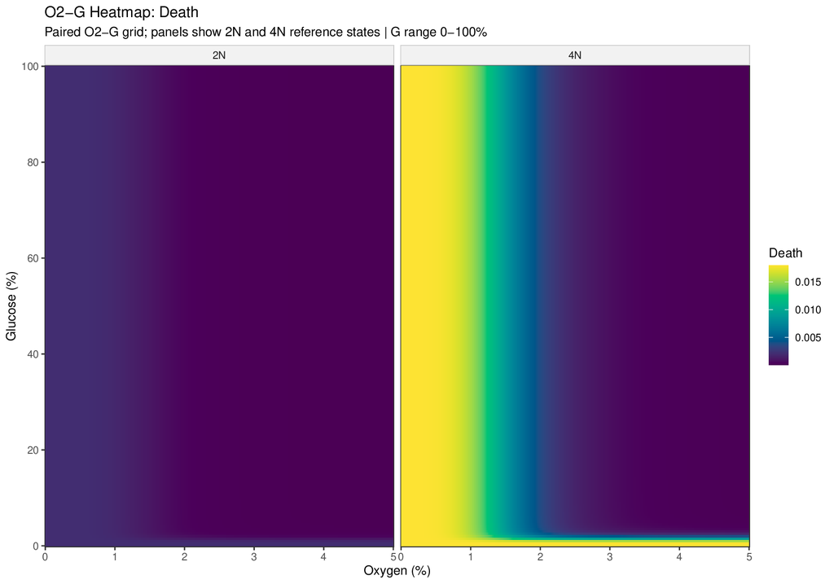

**Figure 3.3.5.2 O2-G Heatmap: Death**

Paired oxygen-glucose grid for fitted death rate; left panel is 2N and right panel is 4N.

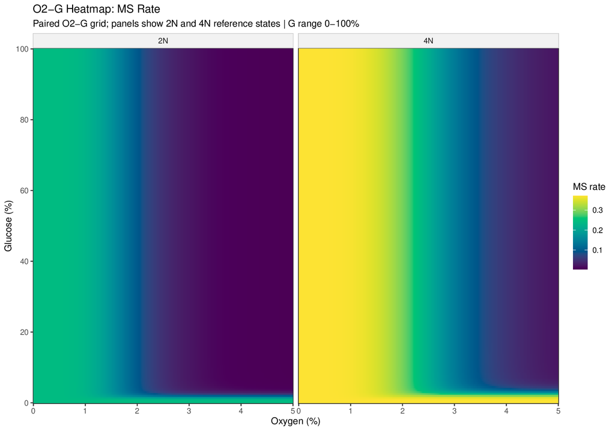

**Figure 3.3.5.3 O2-G Heatmap: MS Rate**

Paired oxygen-glucose grid for fitted missegregation rate; left panel is 2N and right panel is 4N.

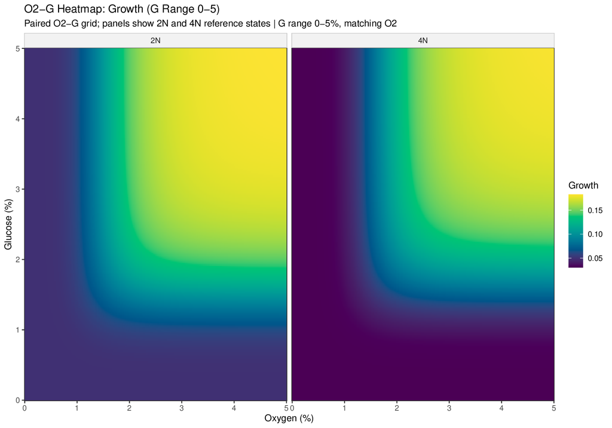

**Figure 3.3.5.4 O2-G Heatmap: Growth (G Range 0-5)**

Paired oxygen-glucose grid for fitted proliferation rate with glucose restricted to 0-5%, matching the oxygen range; left panel is 2N and right panel is 4N.

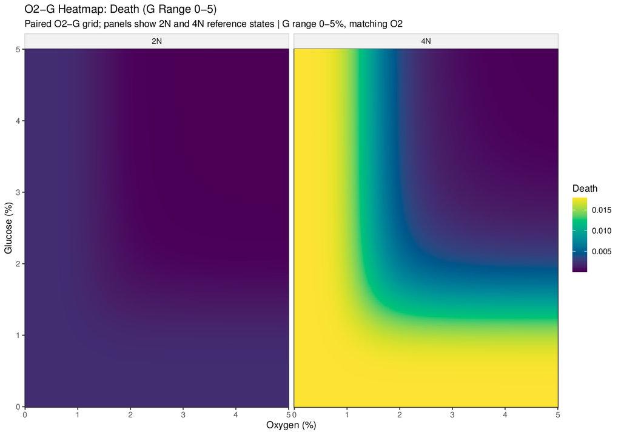

**Figure 3.3.5.5 O2-G Heatmap: Death (G Range 0-5)**

Paired oxygen-glucose grid for fitted death rate with glucose restricted to 0-5%, matching the oxygen range; left panel is 2N and right panel is 4N.

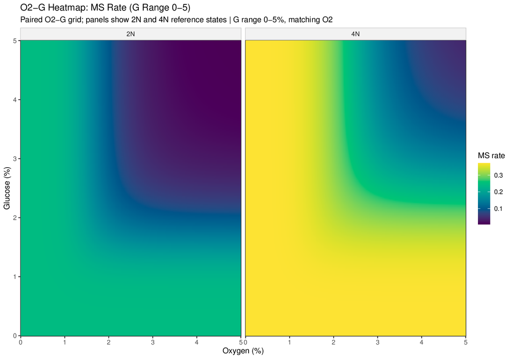

**Figure 3.3.5.6 O2-G Heatmap: MS Rate (G Range 0-5)**

Paired oxygen-glucose grid for fitted missegregation rate with glucose restricted to 0-5%, matching the oxygen range; left panel is 2N and right panel is 4N.